# Practical Machine Learning Course Project

Petra C. Stone

1/21/2017

## Qualitative Activity Recognition of Weight Lifting Exercises

This is a course project for the Practical Machine Learning Course (John Hopkins Data Science Specialization Track, Coursera). Using a dataset from a 2011 study[^1] on weight lifting, the project goal is to use machine learning to predict which technique was used when lifting the dumbell (the technically correct method or one of 4 common mistakes the users were asked to perform)[^2]. The goal of the original study was to determine if mistakes could be detected automatically by wearable devices and thereby provide user feedback on the quality of the exercise.

### Project Brief

> Predict the manner in which they did the exercise. This is the “classe” variable in the training set. You should create a report describing how you built your model, how you used cross validation, what you think the expected out of sample error is, and why you made the choices you did. You will also use your prediction model to predict 20 different test cases.

## Data Exploration

The aim of exploration is to understand the data, reduce irrelevant or redundant features and select the most appropriate features. The paper describes the data set. Each user did 10 repetitions of each “classe” in sequence from A to E. The sensors had a sampling rate of 45Hz (approx 45 samples per second) taking raw measurements from the accelerometors, gyroscopes and magnetometers on the belt, forearm, arm and dumbbell. Aggregate window summaries were calculated at windows of approx 1 second.

Outline of the data:

- Identifier columns for row (`X`) and user (`user_name`)
- Sampling window id (`num_window`) and a marker for calculation of derived features (`new_window`)
- Sampling timestamps (`raw_timestamp_part_1`, `raw_timestamp_part_2`, `cvtd_timestamp`)
- 52 raw sensor measurements per sample (from accelerometer, gyro and magnetoscope on the belt, arm, forearm and dumbell)
- 100 derived features calculated for every approx 45 samples (variance, kurtosis etc. for each raw measurement in the window)
- The `classe` variable (the outcome variable )

```r
  # Load provided training set
  origTraining <- read.csv("pml-training.csv", na.strings = c("NA","#DIV/0!") )
  dim(origTraining)
```

```
## [1] 19622   160
```

```r
  idCols <- c(
      "X", "user_name", "new_window",
      "raw_timestamp_part_1", "raw_timestamp_part_2",
      "cvtd_timestamp", "num_window"
    )
  idVars <- origTraining[, names(origTraining) %in% idCols  ]
  str( idVars )
```

```
## 'data.frame':    19622 obs. of  7 variables:
##  $ X                   : int  1 2 3 4 5 6 7 8 9 10 ...
##  $ user_name           : Factor w/ 6 levels "adelmo","carlitos",..: 2 2 2 2 2 2 2 2 2 2 ...
##  $ raw_timestamp_part_1: int  1323084231 1323084231 1323084231 1323084232 1323084232 1323084232 1323084232 1323084232 1323084232 1323084232 ...
##  $ raw_timestamp_part_2: int  788290 808298 820366 120339 196328 304277 368296 440390 484323 484434 ...
##  $ cvtd_timestamp      : Factor w/ 20 levels "02/12/2011 13:32",..: 9 9 9 9 9 9 9 9 9 9 ...
##  $ new_window          : Factor w/ 2 levels "no","yes": 1 1 1 1 1 1 1 1 1 1 ...
##  $ num_window          : int  11 11 11 12 12 12 12 12 12 12 ...
```

We can see that the derived features are mostly NA values, seeing as they were only calculated for every 45 samples:

```r
  ptn <- "avg_|var_|stddev_|max_|min_|amplitude_|kurtosis_|skewness_"
  derivedFeatures <- origTraining[,grep(ptn, names(origTraining))]
  mean(is.na(derivedFeatures))
```

```
## [1] 0.9810937
```

```r
  str( derivedFeatures )
```

```
## 'data.frame':    19622 obs. of  100 variables:
##  $ kurtosis_roll_belt      : num  NA NA NA NA NA NA NA NA NA NA ...
##  $ kurtosis_picth_belt     : num  NA NA NA NA NA NA NA NA NA NA ...
##  $ kurtosis_yaw_belt       : logi  NA NA NA NA NA NA ...
##  $ skewness_roll_belt      : num  NA NA NA NA NA NA NA NA NA NA ...
##  $ skewness_roll_belt.1    : num  NA NA NA NA NA NA NA NA NA NA ...
##  $ skewness_yaw_belt       : logi  NA NA NA NA NA NA ...
##  $ max_roll_belt           : num  NA NA NA NA NA NA NA NA NA NA ...
##  $ max_picth_belt          : int  NA NA NA NA NA NA NA NA NA NA ...
##  $ max_yaw_belt            : num  NA NA NA NA NA NA NA NA NA NA ...
##  $ min_roll_belt           : num  NA NA NA NA NA NA NA NA NA NA ...
##  $ min_pitch_belt          : int  NA NA NA NA NA NA NA NA NA NA ...
##  $ min_yaw_belt            : num  NA NA NA NA NA NA NA NA NA NA ...
##  $ amplitude_roll_belt     : num  NA NA NA NA NA NA NA NA NA NA ...
##  $ amplitude_pitch_belt    : int  NA NA NA NA NA NA NA NA NA NA ...
```

[output cut: 86 more lines]

The raw measurements do not contain any missing values:

```r
  rawFeatures <- origTraining[, -grep(ptn, names( origTraining ))  ]
  rawFeatures <- rawFeatures[, !names(rawFeatures) %in% c(idCols, "classe") ]
  mean(is.na(rawFeatures))
```

```
## [1] 0
```

```r
  str( rawFeatures )
```

```
## 'data.frame':    19622 obs. of  52 variables:
##  $ roll_belt           : num  1.41 1.41 1.42 1.48 1.48 1.45 1.42 1.42 1.43 1.45 ...
##  $ pitch_belt          : num  8.07 8.07 8.07 8.05 8.07 8.06 8.09 8.13 8.16 8.17 ...
##  $ yaw_belt            : num  -94.4 -94.4 -94.4 -94.4 -94.4 -94.4 -94.4 -94.4 -94.4 -94.4 ...
##  $ total_accel_belt    : int  3 3 3 3 3 3 3 3 3 3 ...
##  $ gyros_belt_x        : num  0 0.02 0 0.02 0.02 0.02 0.02 0.02 0.02 0.03 ...
##  $ gyros_belt_y        : num  0 0 0 0 0.02 0 0 0 0 0 ...
##  $ gyros_belt_z        : num  -0.02 -0.02 -0.02 -0.03 -0.02 -0.02 -0.02 -0.02 -0.02 0 ...
##  $ accel_belt_x        : int  -21 -22 -20 -22 -21 -21 -22 -22 -20 -21 ...
##  $ accel_belt_y        : int  4 4 5 3 2 4 3 4 2 4 ...
##  $ accel_belt_z        : int  22 22 23 21 24 21 21 21 24 22 ...
##  $ magnet_belt_x       : int  -3 -7 -2 -6 -6 0 -4 -2 1 -3 ...
##  $ magnet_belt_y       : int  599 608 600 604 600 603 599 603 602 609 ...
##  $ magnet_belt_z       : int  -313 -311 -305 -310 -302 -312 -311 -313 -312 -308 ...
##  $ roll_arm            : num  -128 -128 -128 -128 -128 -128 -128 -128 -128 -128 ...
```

[output cut: 38 more lines]

### Feature Selection

We need to disgard the id columns and the derived features columns. This is because:

1. We are not predicting from window summaries in the test set but from discrete samples, using raw measurements.
2. The id and timestamp columns would bias the model and are not relevant to our prediction task.
3. The derived features are mostly 98% NA and would not help in prediction.

```r
  cleanTraining <- origTraining[, !names(origTraining) %in% c(idCols, names(derivedFeatures)) ]
```

This leaves us with a dataset of 52 predictors and the `classe` variable.

```r
  dim(cleanTraining)
```

```
## [1] 19622    53
```

### Visualisation

Let’s look at these remaining 52 predictors, looking for outliers, skewness, imbalances in outcome/predictors, and explainable groups of points/patterns.

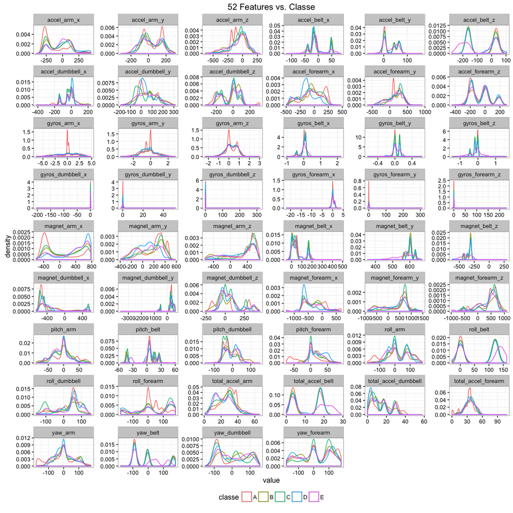

```r
  require(reshape2)
  # Plot the features
  m <- melt( cleanTraining, id.vars=c('classe')  )
  m$variable <- factor(m$variable, levels = sort( levels(m$variable) ) )

  require(ggplot2)
  ggplot( m,
    aes(value, color=classe ) ) +
    geom_density() +
    facet_wrap(~variable, ncol=6, scales="free") +
    ggtitle( "52 Features vs. Classe") +
    theme_bw() +
    theme( legend.position="bottom")
```

The distribution of the variables don’t seem normally distributed and would suit a model that does not make assumptions about the distribution of the data (non-parametric) as opposed to a linear model. The dumbell and forearm gyros are particularly skewed and some of the other metrics are multi-modal eg. `roll_belt`, `yaw_forearm`.

We can check for near zero vars.

```r
  require(caret)
  # Check for near zero variance predictors
  nzv <- nearZeroVar(cleanTraining, saveMetrics=T)
  length( cleanTraining[,nzv$nzv==T] ); length( cleanTraining[,nzv$zeroVar==T] )
```

```
## [1] 0
```

```
## [1] 0
```

There are none so we can proceed with evaluating some models. First we need to split the cleaned training set into subsets of training and validation sets so we can validate/tune the models based on their performance.

```r
  # Set a seed to make the research reproducible
  set.seed(91801)

  # Subset the training set into a validation and training set
  inTrain <- createDataPartition(cleanTraining$classe, p=0.6, list=FALSE)
  training <- cleanTraining[inTrain,]
  validation <- cleanTraining[-inTrain,]
```

## Train Models

I am comparing 6 models (from simpler to more complex):

1. Naive Bayes Classification
2. K-Nearest Neighbours Classification
3. CART
4. Random Forest
5. GBM
6. XgBoost

The first 2 models (Bayes and KNN) are the simplest approaches. KNN requires some transformation of the data (standardising mean=0, stddev=1). The last 4 are tree-based. In order to get some perspective on the more complex final 3 tree ensemble methods I modeled a single decision tree to illustrate the building blocks of what these more complex algorithms are based on.

For cross-validation I used 5-Fold Cross Validation to train the models. I used 5-Fold because rather than the default 10 in order to speed up training. I then estimated the out of sample error using the accuracy measure on the validation set. Leveraging parallel processing in R really helps to speed this step up:

```r
  require(parallel)
  require(doParallel)

  fitControl <- trainControl(method = "cv", number = 5, verboseIter=F, allowParallel = T)

  set.seed(81978)

  # Use parallel processing
  cluster <- makeCluster(detectCores() - 1)
  registerDoParallel(cluster)

  # Naive Bayes
  system.time( nbFit <- train(classe~., data=training, method="nb", trControl = fitControl) )
```

```
##    user  system elapsed
##   1.083   0.443  67.776
```

```r
  # KNN
  # predict.train will automatically apply the same transformation as the fit to any new data
  knnGrid <- expand.grid(.k=1:7)
  system.time( knnFit <- train(classe~., data=training, method="knn", preProcess=c('center','scale'), tuneGrid=knnGrid, trControl=fitControl) )
```

```
##    user  system elapsed
##   1.060   0.188  65.519
```

```r
  # CART
  cartGrid<- expand.grid(.cp=0.0001)
  system.time( treeFit <- train(classe~., data=training, method="rpart", trControl=fitControl, tuneGrid= cartGrid) )
```

```
##    user  system elapsed
##   1.091   0.044   2.316
```

```r
  # Random Forest
  system.time( rfFit <- train(classe~., data=training, method="rf", trControl = fitControl ) )
```

```
##    user  system elapsed
##  39.635   0.647 234.602
```

```r
  # GBM
  gbmGrid <- expand.grid( .interaction.depth = (1:5)*2, .n.trees = (3:10)*25, .shrinkage = .1, .n.minobsinnode = 10 )
  system.time( gbmFit <- train(classe ~ ., training, method = "gbm", trControl= fitControl, verbose=F, tuneGrid = gbmGrid) )
```

```
##    user  system elapsed
## 101.330   1.094 570.311
```

```r
  # XGB
  system.time( xgbFit <- train(classe ~ ., data = training, method = "xgbTree", trControl= fitControl, verbose=F) )
```

```
##    user  system elapsed
##  22.056   0.487 720.506
```

```r
  # Stop parallel processing
  stopCluster(cluster)
  registerDoSEQ()
```

```r
  nbFit
```

```
## Naive Bayes
##
## 11776 samples
##    52 predictor
##     5 classes: 'A', 'B', 'C', 'D', 'E'
##
## No pre-processing
## Resampling: Cross-Validated (5 fold)
## Summary of sample sizes: 9420, 9422, 9420, 9421, 9421
## Resampling results across tuning parameters:
##
##   usekernel  Accuracy   Kappa
##   FALSE      0.4953222  0.3764153
##    TRUE      0.7307232  0.6568960
##
## Tuning parameter 'fL' was held constant at a value of 0
## Tuning
##  parameter 'adjust' was held constant at a value of 1
## Accuracy was used to select the optimal model using  the largest value.
## The final values used for the model were fL = 0, usekernel = TRUE
##  and adjust = 1.
```

```r
  knnFit
```

```
## k-Nearest Neighbors
##
## 11776 samples
##    52 predictor
##     5 classes: 'A', 'B', 'C', 'D', 'E'
##
## Pre-processing: centered (52), scaled (52)
## Resampling: Cross-Validated (5 fold)
## Summary of sample sizes: 9422, 9420, 9421, 9421, 9420
## Resampling results across tuning parameters:
##
##   k  Accuracy   Kappa
##   1  0.9809780  0.9759369
##   2  0.9638248  0.9542400
##   3  0.9592388  0.9484236
##   4  0.9465862  0.9324216
##   5  0.9402172  0.9243442
##   6  0.9327445  0.9148882
##   7  0.9286683  0.9097152
##
## Accuracy was used to select the optimal model using  the largest value.
## The final value used for the model was k = 1.
```

```r
  treeFit
```

```
## CART
##
## 11776 samples
##    52 predictor
##     5 classes: 'A', 'B', 'C', 'D', 'E'
##
## No pre-processing
## Resampling: Cross-Validated (5 fold)
## Summary of sample sizes: 9422, 9421, 9420, 9421, 9420
## Resampling results:
##
##   Accuracy   Kappa
##   0.9118548  0.8885087
##
## Tuning parameter 'cp' was held constant at a value of 1e-04
##
```

```r
  rfFit
```

```
## Random Forest
##
## 11776 samples
##    52 predictor
##     5 classes: 'A', 'B', 'C', 'D', 'E'
##
## No pre-processing
## Resampling: Cross-Validated (5 fold)
## Summary of sample sizes: 9420, 9422, 9421, 9420, 9421
## Resampling results across tuning parameters:
##
##   mtry  Accuracy   Kappa
##    2    0.9886209  0.9856040
##   27    0.9894699  0.9866787
##   52    0.9825918  0.9779772
##
## Accuracy was used to select the optimal model using  the largest value.
## The final value used for the model was mtry = 27.
```

```r
  gbmFit
```

```
## Stochastic Gradient Boosting
##
## 11776 samples
##    52 predictor
##     5 classes: 'A', 'B', 'C', 'D', 'E'
##
## No pre-processing
## Resampling: Cross-Validated (5 fold)
## Summary of sample sizes: 9420, 9421, 9421, 9421, 9421
## Resampling results across tuning parameters:
##
##   interaction.depth  n.trees  Accuracy   Kappa
##    2                  75      0.8845956  0.8538838
##    2                 100      0.9056553  0.8805941
##    2                 125      0.9185629  0.8969194
```

[output cut: 44 more lines]

```r
  xgbFit
```

```
## eXtreme Gradient Boosting
##
## 11776 samples
##    52 predictor
##     5 classes: 'A', 'B', 'C', 'D', 'E'
##
## No pre-processing
## Resampling: Cross-Validated (5 fold)
## Summary of sample sizes: 9421, 9422, 9421, 9420, 9420
## Resampling results across tuning parameters:
##
##   eta  max_depth  colsample_bytree  subsample  nrounds  Accuracy
##   0.3  1          0.6               0.50        50      0.7991681
##   0.3  1          0.6               0.50       100      0.8609024
##   0.3  1          0.6               0.50       150      0.8863779
##   0.3  1          0.6               0.75        50      0.7963643
##   0.3  1          0.6               0.75       100      0.8557223
##   0.3  1          0.6               0.75       150      0.8862084
##   0.3  1          0.6               1.00        50      0.7995068
##   0.3  1          0.6               1.00       100      0.8542788
##   0.3  1          0.6               1.00       150      0.8836602
##   0.3  1          0.8               0.50        50      0.8017982
##   0.3  1          0.8               0.50       100      0.8610723
##   0.3  1          0.8               0.50       150      0.8907083
##   0.3  1          0.8               0.75        50      0.8021390
##   0.3  1          0.8               0.75       100      0.8550431
##   0.3  1          0.8               0.75       150      0.8859535
##   0.3  1          0.8               1.00        50      0.8019702
##   0.3  1          0.8               1.00       100      0.8546185
##   0.3  1          0.8               1.00       150      0.8849346
##   0.3  2          0.6               0.50        50      0.9089664
##   0.3  2          0.6               0.50       100      0.9543126
##   0.3  2          0.6               0.50       150      0.9703629
##   0.3  2          0.6               0.75        50      0.9123627
##   0.3  2          0.6               0.75       100      0.9531235
##   0.3  2          0.6               0.75       150      0.9692583
##   0.3  2          0.6               1.00        50      0.9114292
##   0.3  2          0.6               1.00       100      0.9502366
##   0.3  2          0.6               1.00       150      0.9658617
##   0.3  2          0.8               0.50        50      0.9127029
```

[output cut: 182 more lines]

```
##   0.9887205
##   0.9639075
##   0.9863581
##   0.9900108
##   0.9632679
##   0.9846408
##   0.9902257
##
## Tuning parameter 'gamma' was held constant at a value of 0
##
## Tuning parameter 'min_child_weight' was held constant at a value of 1
## Accuracy was used to select the optimal model using  the largest value.
## The final values used for the model were nrounds = 150, max_depth = 3,
##  eta = 0.4, gamma = 0, colsample_bytree = 0.8, min_child_weight = 1
##  and subsample = 1.
```

## Model Evaluation

The confusionMatrix function in Caret shows how the model performs out of sample:

```r
  # Naive Bayes
  nbPredict <- predict( nbFit, validation )
  nbAccuracy <- confusionMatrix(nbPredict, validation$classe)$overall[1]

  # KNN
  knnPredict <- predict(knnFit, validation )
  knnAccuracy <- confusionMatrix(knnPredict, validation$classe)$overall[1]

  # CART
  treePredict <- predict(treeFit, validation )
  treeAccuracy <- confusionMatrix(treePredict, validation$classe)$overall[1]

  # RF
  rfPredict <- predict(rfFit, validation )
  rfAccuracy <- confusionMatrix(rfPredict, validation$classe)$overall[1]

  # GBM
  gbmPredict <- predict(gbmFit, validation )
  gbmAccuracy <- confusionMatrix(gbmPredict, validation$classe)$overall[1]

  # XGB
  xgbPredict <- predict(xgbFit, validation )
  xgbAccuracy <- confusionMatrix(xgbPredict, validation$classe)$overall[1]
```

### Out of Sample Error

This table compares the accuracy rate of the 6 models when cross-validated with the held-out validation set:

Comparing Out of Sample Error on 6 Models

| model | notes | params | timing_mins | accuracy |
| --- | --- | --- | --- | --- |
| Naive Bayes | 5-Fold CV | default | 1.0882 | 0.7345 |
| KNN | 5-Fold CV | k=1-7 | 1.0601 | 0.9870 |
| CART | 5-Fold CV | cp=.0001 | 0.0468 | 0.9242 |
| Random Forest | 5-Fold CV | default | 3.8732 | 0.9912 |
| GBM (tuned) | 5-Fold CV | tuned n.trees, interaction.depth | 9.5423 | 0.9927 |
| xgbTree | 5-Fold CV | default | 11.9086 | 0.9929 |

The 3 tree ensemble methods had the highest rate of accuracy (>.99), with KNN doing well at .98, CART doing reasonably well at .92 and Naive Bayes performing poorly at .73. xgbTree and Random Forests performed very well “out of the box” without any tuning, but xgbTree took 3 times longer than Random Forest. KNN, CART and GBM all needed additional tuning as their initial “out of the box” results were poor.

### Variable Importance for models

Variable importance in tree models can aid in feature selection, helping us to understand which covariates were most important. The Caret package provides an importance metric on a scale 0-100. For example, the importance metric for Random Forest is based on averaged Gini decrease in node impurities over all trees in the forest. Other models may use different criteria for importance.

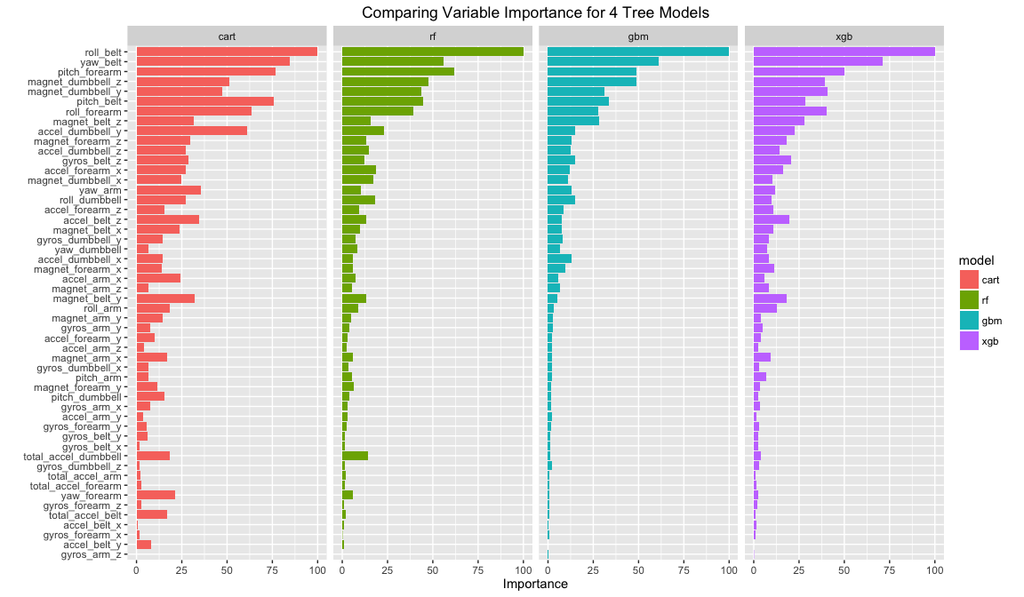

### Accuracy

The accuracy graphs visualise the tuning parameters selected during training for the best fit. Models can be tuned with different parameters to see if accuracy improves.

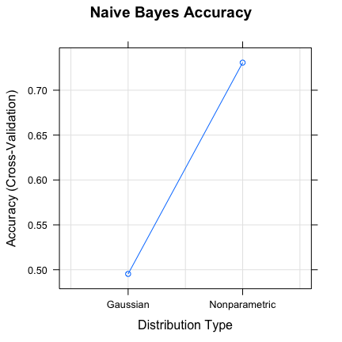

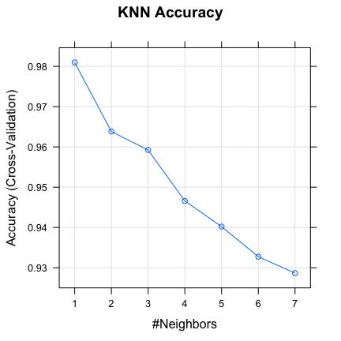

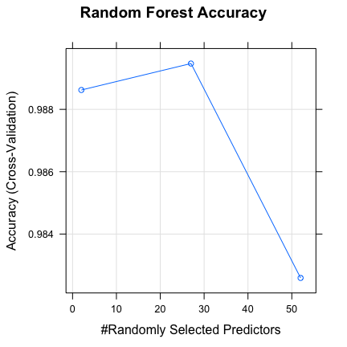

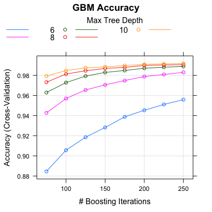

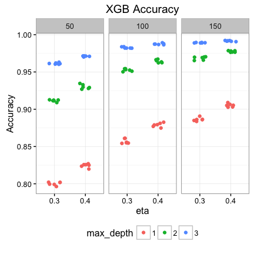

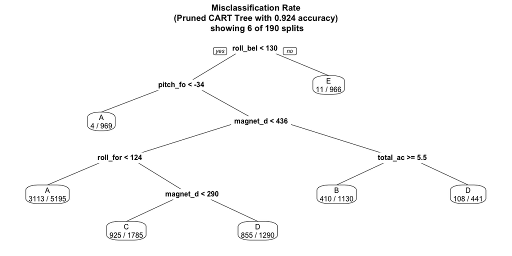

## Predict 20 Test Cases

We have been given 20 samples to predict for the quiz:

```r
  quiz <- read.csv("pml-testing.csv", na.strings = c("NA","#DIV/0!") )

  # Predict on ultimate test set
  q0 <- predict(nbFit, quiz )
  q1 <- predict(knnFit, quiz )
  q2 <- predict(treeFit, quiz )
  q3 <- predict(rfFit, quiz )
  q4 <- predict(gbmFit, quiz )
  q5 <- predict(xgbFit, quiz )
```

Naive Bayes and CART disagreed with the other 4 models (which all had the same answers):

```r
  result <- data.frame( problem_id=quiz$problem_id, naive=q0, knn=q1, cart=q2, rf=q3, gbm=q4, xgb=q5)
  result
```

```
##    problem_id naive knn cart rf gbm xgb
## 1           1     A   B    B  B   B   B
## 2           2     A   A    A  A   A   A
## 3           3     A   B    B  B   B   B
## 4           4     A   A    A  A   A   A
## 5           5     A   A    A  A   A   A
## 6           6     E   E    B  E   E   E
## 7           7     D   D    D  D   D   D
## 8           8     C   B    B  B   B   B
## 9           9     A   A    A  A   A   A
## 10         10     A   A    A  A   A   A
## 11         11     A   B    C  B   B   B
## 12         12     A   C    C  C   C   C
## 13         13     B   B    B  B   B   B
## 14         14     A   A    A  A   A   A
## 15         15     E   E    E  E   E   E
## 16         16     A   E    E  E   E   E
## 17         17     A   A    A  A   A   A
## 18         18     B   B    B  B   B   B
## 19         19     A   B    B  B   B   B
## 20         20     B   B    B  B   B   B
```

## Appendix

### Predict on actual test data

It would be interesting to see how the models perform on the entire unseen portion of the WLE dataset which can be downloaded from the site. The training set we were provided with only contained 50% of the samples so we can test on the other 50% for a better out of sample estimate:

```r
  allData <- read.csv("raw.csv", na.strings = c("NA","#DIV/0!") )
  allData <- allData[, !names(allData) %in% c(idCols, names(derivedFeatures)) ]

  require(dplyr)
  unseenData <- anti_join(allData, origTraining)
  dim(unseenData)
```

```
## [1] 19620    53
```

```r
  unseenData <- unseenData[complete.cases(unseenData),]
  dim(unseenData)
```

```
## [1] 19619    53
```

```r
  q0 <- confusionMatrix( predict(nbFit,  unseenData ), unseenData$classe )$overall[1]
  q1 <- confusionMatrix( predict(knnFit, unseenData ), unseenData$classe )$overall[1]
  q2 <- confusionMatrix( predict(treeFit, unseenData ), unseenData$classe )$overall[1]
  q3 <- confusionMatrix( predict(rfFit, unseenData ), unseenData$classe )$overall[1]
  q4 <- confusionMatrix( predict(gbmFit, unseenData ), unseenData$classe )$overall[1]
  q5 <- confusionMatrix( predict(xgbFit, unseenData ), unseenData$classe )$overall[1]
```

It’s quite surprising how well each model performed on the unseen data:

Comparing Accuracy on 6 Models for Validation Set and Unseen data

| dataset | naive | knn | cart | rf | gbm | xgb |
| --- | --- | --- | --- | --- | --- | --- |
| wle | 0.7216 | 0.9845 | 0.9196 | 0.9910 | 0.9913 | 0.9920 |
| validation | 0.7345 | 0.9870 | 0.9242 | 0.9912 | 0.9927 | 0.9929 |

[^1]: Velloso, E.; Bulling, A.; Gellersen, H.; Ugulino, W.; Fuks, H. Qualitative Activity Recognition of Weight Lifting Exercises. Proceedings of 4th International Conference in Cooperation with SIGCHI (Augmented Human ’13) . Stuttgart, Germany: ACM SIGCHI, 2013. http://groupware.les.inf.puc-rio.br/har#ixzz4Vv3AVlgw http://groupware.les.inf.puc-rio.br/public/papers/2013.Velloso.QAR-WLE.pdf
[^2]: The exercises were performed by six male participants aged between 20-28 years, with little weight lifting experience. The participants wore devices which measured accelerometer, magnetometer and gyroscope statistics on the arm, belt, glove and dumbell. They were asked to perform one set of 10 repetitions of the Unilateral Dumbbell Biceps Curl in five different fashions: exactly according to the specification (Class A), throwing the elbows to the front (Class B), lifting the dumbbell only halfway (Class C), lowering the dumbbell only halfway (Class D) and throwing the hips to the front (Class E). Class A corresponds to the specified execution of the exercise, while the other 4 classes correspond to common mistakes.